# This notebook will show step to step model building for wine quality evaluation

Developed by: Tianxia Zhao

- Read the data from two csv files
- Data analysis and visulaization
- Regression model
- Classification model
- Model evaluation with metrics and Summary

## Part 1. Load in the data

```python
## this part is not necessary if the code and owrking directory is in the same folder with data
#import os
#os.chdir('E:\\undergoingstudy\\dataassignments\\ON3')
#cwd = os.getcwd()
#print(cwd)
```

[output not shown]

```python
import pandas as pd
import numpy as np
import matplotlib.pyplot as plt
#read the two wine quality
redwine = pd.read_csv('winequality-red.csv')
whitewine = pd.read_csv('winequality-white.csv')
# since the two data has the same number of columns, concatenate the two datasets
allwine=pd.concat((redwine,whitewine), axis=0)
```

```python
allwine.describe()
```

|  | fixed acidity | volatile acidity | citric acid | residual sugar | chlorides | free sulfur dioxide | total sulfur dioxide | density | pH | sulphates | alcohol | quality |
| --- | --- | --- | --- | --- | --- | --- | --- | --- | --- | --- | --- | --- |
| count | 6497.000000 | 6497.000000 | 6497.000000 | 6497.000000 | 6497.000000 | 6497.000000 | 6497.000000 | 6497.000000 | 6497.000000 | 6497.000000 | 6497.000000 | 6497.000000 |
| mean | 7.215307 | 0.339666 | 0.318633 | 5.443235 | 0.056034 | 30.525319 | 115.744574 | 0.994697 | 3.218501 | 0.531268 | 10.491801 | 5.818378 |
| std | 1.296434 | 0.164636 | 0.145318 | 4.757804 | 0.035034 | 17.749400 | 56.521855 | 0.002999 | 0.160787 | 0.148806 | 1.192712 | 0.873255 |
| min | 3.800000 | 0.080000 | 0.000000 | 0.600000 | 0.009000 | 1.000000 | 6.000000 | 0.987110 | 2.720000 | 0.220000 | 8.000000 | 3.000000 |
| 25% | 6.400000 | 0.230000 | 0.250000 | 1.800000 | 0.038000 | 17.000000 | 77.000000 | 0.992340 | 3.110000 | 0.430000 | 9.500000 | 5.000000 |
| 50% | 7.000000 | 0.290000 | 0.310000 | 3.000000 | 0.047000 | 29.000000 | 118.000000 | 0.994890 | 3.210000 | 0.510000 | 10.300000 | 6.000000 |
| 75% | 7.700000 | 0.400000 | 0.390000 | 8.100000 | 0.065000 | 41.000000 | 156.000000 | 0.996990 | 3.320000 | 0.600000 | 11.300000 | 6.000000 |
| max | 15.900000 | 1.580000 | 1.660000 | 65.800000 | 0.611000 | 289.000000 | 440.000000 | 1.038980 | 4.010000 | 2.000000 | 14.900000 | 9.000000 |

```python
allwine.dtypes
```

```
fixed acidity           float64
volatile acidity        float64
citric acid             float64
residual sugar          float64
chlorides               float64
free sulfur dioxide     float64
total sulfur dioxide    float64
density                 float64
pH                      float64
sulphates               float64
alcohol                 float64
quality                   int64
dtype: object
```

```python
allwine.info()
```

```
<class 'pandas.core.frame.DataFrame'>
Int64Index: 6497 entries, 0 to 4897
Data columns (total 12 columns):
fixed acidity           6497 non-null float64
volatile acidity        6497 non-null float64
citric acid             6497 non-null float64
residual sugar          6497 non-null float64
chlorides               6497 non-null float64
free sulfur dioxide     6497 non-null float64
total sulfur dioxide    6497 non-null float64
density                 6497 non-null float64
pH                      6497 non-null float64
sulphates               6497 non-null float64
alcohol                 6497 non-null float64
quality                 6497 non-null int64
dtypes: float64(11), int64(1)
memory usage: 659.9 KB
```

```python
allwine.head(7)  # read the first 7 rows to take a look of the data
```

|  | fixed acidity | volatile acidity | citric acid | residual sugar | chlorides | free sulfur dioxide | total sulfur dioxide | density | pH | sulphates | alcohol | quality |
| --- | --- | --- | --- | --- | --- | --- | --- | --- | --- | --- | --- | --- |
| 0 | 7.4 | 0.70 | 0.00 | 1.9 | 0.076 | 11.0 | 34.0 | 0.9978 | 3.51 | 0.56 | 9.4 | 5 |
| 1 | 7.8 | 0.88 | 0.00 | 2.6 | 0.098 | 25.0 | 67.0 | 0.9968 | 3.20 | 0.68 | 9.8 | 5 |
| 2 | 7.8 | 0.76 | 0.04 | 2.3 | 0.092 | 15.0 | 54.0 | 0.9970 | 3.26 | 0.65 | 9.8 | 5 |
| 3 | 11.2 | 0.28 | 0.56 | 1.9 | 0.075 | 17.0 | 60.0 | 0.9980 | 3.16 | 0.58 | 9.8 | 6 |
| 4 | 7.4 | 0.70 | 0.00 | 1.9 | 0.076 | 11.0 | 34.0 | 0.9978 | 3.51 | 0.56 | 9.4 | 5 |
| 5 | 7.4 | 0.66 | 0.00 | 1.8 | 0.075 | 13.0 | 40.0 | 0.9978 | 3.51 | 0.56 | 9.4 | 5 |
| 6 | 7.9 | 0.60 | 0.06 | 1.6 | 0.069 | 15.0 | 59.0 | 0.9964 | 3.30 | 0.46 | 9.4 | 5 |

**Comments**:  
The above study show that the data is clean, with non missing data, and the 11 feature variables are all float numeric number, the label or the predict variable is integer

## Part 2. Data Visualization and Analysis

```python
import matplotlib.pyplot as plt
import seaborn as sns
sns.set_style('whitegrid')
%matplotlib inline
```

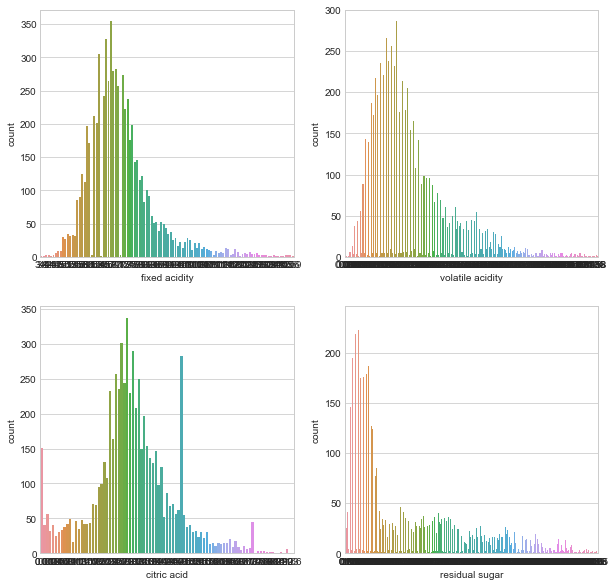

```python
fig, axarr  = plt.subplots(2,2,figsize=(10,10))
sns.countplot(x='fixed acidity', data=allwine, ax=axarr[0,0])
sns.countplot(x='volatile acidity', data=allwine, ax=axarr[0,1])
sns.countplot(x='citric acid', data=allwine, ax=axarr[1,0])
sns.countplot(x='residual sugar', data=allwine, ax=axarr[1,1])
```

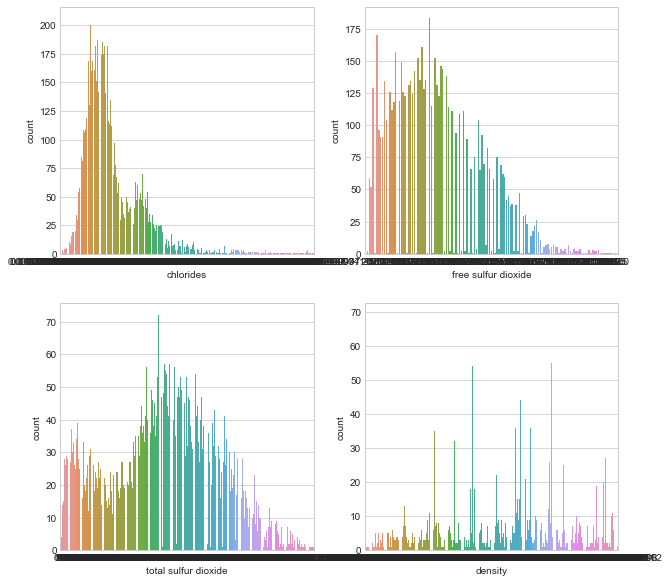

```python
fig, axarr  = plt.subplots(2,2,figsize=(10,10))
sns.countplot(x='chlorides', data=allwine, ax=axarr[0,0])
sns.countplot(x='free sulfur dioxide', data=allwine, ax=axarr[0,1])
sns.countplot(x='total sulfur dioxide', data=allwine, ax=axarr[1,0])
sns.countplot(x='density', data=allwine, ax=axarr[1,1])
```

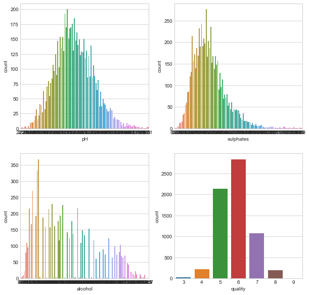

```python
fig, axarr  = plt.subplots(2,2,figsize=(10,10))
sns.countplot(x='pH', data=allwine, ax=axarr[0,0])
sns.countplot(x='sulphates', data=allwine, ax=axarr[0,1])
sns.countplot(x='alcohol', data=allwine, ax=axarr[1,0])
sns.countplot(x='quality', data=allwine, ax=axarr[1,1])
```

Now we can study the relationship between variables, but we just show two as demo

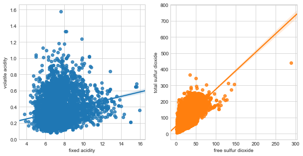

```python
fig, (axis1, axis2)  = plt.subplots(1, 2,figsize=(10,5))
sns.regplot(x='fixed acidity', y='volatile acidity', data=allwine, ax=axis1)
sns.regplot(x='free sulfur dioxide', y='total sulfur dioxide', data=allwine, ax=axis2)
```

**Comments**: The left figure shows that fixed acidity and volatile acidity is not very correlated.  
But the right figure shows that free sulfur dioxide and total sulfure dioxide are correlated!  
We will use Seaborn heatmap to check the correlation on the whoel dataset.

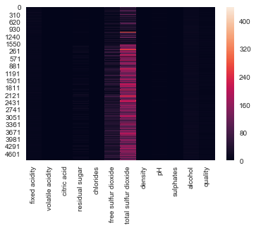

```python
sns.set()
ax=sns.heatmap(allwine)
```

```python
allwine=allwine.drop('free sulfur dioxide',axis=1)
```

```python
allwine.head(5)
```

|  | fixed acidity | volatile acidity | citric acid | residual sugar | chlorides | total sulfur dioxide | density | pH | sulphates | alcohol | quality |
| --- | --- | --- | --- | --- | --- | --- | --- | --- | --- | --- | --- |
| 0 | 7.4 | 0.70 | 0.00 | 1.9 | 0.076 | 34.0 | 0.9978 | 3.51 | 0.56 | 9.4 | 5 |
| 1 | 7.8 | 0.88 | 0.00 | 2.6 | 0.098 | 67.0 | 0.9968 | 3.20 | 0.68 | 9.8 | 5 |
| 2 | 7.8 | 0.76 | 0.04 | 2.3 | 0.092 | 54.0 | 0.9970 | 3.26 | 0.65 | 9.8 | 5 |
| 3 | 11.2 | 0.28 | 0.56 | 1.9 | 0.075 | 60.0 | 0.9980 | 3.16 | 0.58 | 9.8 | 6 |
| 4 | 7.4 | 0.70 | 0.00 | 1.9 | 0.076 | 34.0 | 0.9978 | 3.51 | 0.56 | 9.4 | 5 |

We will check the label to be predicted to get an idea of its distribution

```
6    2836
5    2138
7    1079
4     216
8     193
3      30
9       5
Name: quality, dtype: int64
```

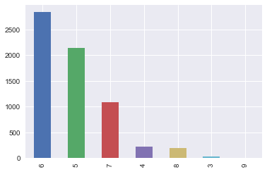

```python
allwine['quality'].value_counts().plot(kind='bar')
allwine['quality'].value_counts()
```

The above summary shows that the wine quality is concentrated to rating 5-7  
It will cause error later for classification, because it is highly imbalanced data.  
The high rating of 9 has only 5 instances, and low rating wine instance number is 30.  
Since the model will be inclined to the classes with the majority of instances, so 5-7 can be predicted better that the lower end and higher end wines.  
**Solution**: This can be done by oversample class 3-4, and 8-9, by duplicating the data,  
or by down sampling the other classes.  
But the dataset is not big enough to afford to be down sampled.  
Or we can use ensemble methods like adaboost, gradient tree boosting, XGboost.  
Due to time limit, I skipped this step. But it can greatly improve accuracy if we adopt the above methods to solve the imbalance issue!

## Part 3. Regression Model

### 3.a. Multilinear regression

```python
from sklearn import preprocessing
from sklearn.preprocessing import LabelEncoder, StandardScaler
from sklearn.metrics import r2_score,mean_squared_error
from sklearn.model_selection import train_test_split,GridSearchCV
import statsmodels.stats as sms
import statsmodels.api as sm
```

```python
ydata=allwine['quality']   # this is the predict data
Xdata=allwine.drop('quality',axis=1)  # this is the independent variables
# split the data into training and testing or validation with 1/3 as testing data
xtrain,xtest,ytrain,ytest=train_test_split(Xdata,ydata, test_size=0.33, random_state=25)
# the scaler cab be used later in the testing data
scaler = preprocessing.StandardScaler().fit(xtrain)
#scaler.mean_
#scaler.scale_
# normalized data
x_tascale=scaler.transform(xtrain) # scaled train data
x_ts=scaler.transform(xtest)  # scaled test data
print("Train x shape:", x_tascale.shape)
print("Test x shape:", x_ts.shape)
```

```
Train x shape: (4352, 10)
Test x shape: (2145, 10)
```

```python
# build the multilinear regression model
model_line_regression = sm.OLS(ytrain,xtrain)
results = model_line_regression.fit()
model_summary = results.summary()
print(model_summary)
```

```
                            OLS Regression Results
==============================================================================
Dep. Variable:                quality   R-squared:                       0.984
Model:                            OLS   Adj. R-squared:                  0.984
Method:                 Least Squares   F-statistic:                 2.724e+04
Date:                Thu, 12 Apr 2018   Prob (F-statistic):               0.00
Time:                        21:59:55   Log-Likelihood:                -4845.8
No. Observations:                4352   AIC:                             9712.
Df Residuals:                    4342   BIC:                             9775.
Df Model:                          10
Covariance Type:            nonrobust
========================================================================================
                           coef    std err          t      P>|t|      [0.025      0.975]
----------------------------------------------------------------------------------------
fixed acidity            0.0041      0.012      0.354      0.723      -0.019       0.027
volatile acidity        -1.4989      0.087    -17.164      0.000      -1.670      -1.328
citric acid             -0.1010      0.096     -1.052      0.293      -0.289       0.087
residual sugar           0.0246      0.003      8.579      0.000       0.019       0.030
chlorides               -1.0369      0.393     -2.641      0.008      -1.806      -0.267
total sulfur dioxide    -0.0013      0.000     -4.640      0.000      -0.002      -0.001
density                  1.9376      0.344      5.630      0.000       1.263       2.612
pH                       0.1821      0.085      2.150      0.032       0.016       0.348
sulphates                0.7559      0.088      8.572      0.000       0.583       0.929
alcohol                  0.3320      0.011     30.332      0.000       0.311       0.353
==============================================================================
Omnibus:                       78.595   Durbin-Watson:                   2.001
Prob(Omnibus):                  0.000   Jarque-Bera (JB):              158.313
Skew:                           0.036   Prob(JB):                     4.20e-35
Kurtosis:                       3.932   Cond. No.                     4.77e+03
==============================================================================

Warnings:
[1] Standard Errors assume that the covariance matrix of the errors is correctly specified.
[2] The condition number is large, 4.77e+03. This might indicate that there are
strong multicollinearity or other numerical problems.
```

```python
# evluate the model by  MSE and R-square
y_train_pred = results.predict(xtrain)
y_valid_pred = results.predict(xtest)

print('OLS Training MSE:', mean_squared_error(ytrain, y_train_pred))
print('OLS Training R2:', r2_score(ytrain, y_train_pred))
print('OLS Validation MSE:', mean_squared_error(ytest, y_valid_pred))
print('OLS Validation R2:', r2_score(ytest, y_valid_pred))
```

```
OLS Training MSE: 0.5428423472548696
OLS Training R2: 0.2873544709590652
OLS Validation MSE: 0.5561550114676193
OLS Validation R2: 0.2719744557375521
```

Mean_squared_error should be small while R2 score should be high (from 0-1)

Now plot the original and predicted for trainging data

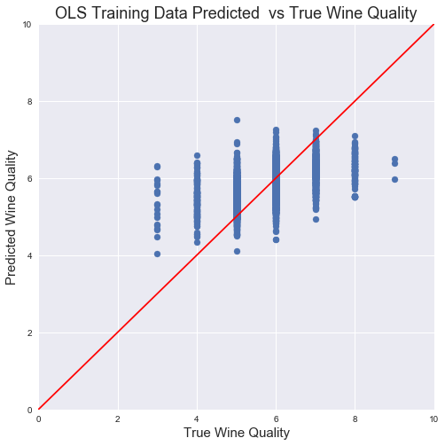

```python
fig = plt.figure(figsize=(8,8))
ax = fig.add_subplot(1,1,1)
ax.scatter(ytrain, y_train_pred)
ax.plot([0, 10], [0, 10], 'r-')
ax.set_xlim([0, 10])
ax.set_ylim([0, 10])
ax.set_xlabel('True Wine Quality', fontsize = 15)
ax.set_ylabel('Predicted Wine Quality', fontsize = 15)
ax.set_title('OLS Training Data Predicted  vs True Wine Quality', fontsize = 18)
plt.show()
```

Now plot the original and predicted for testing data

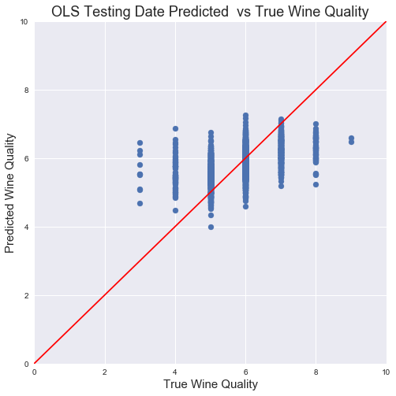

```python
fig = plt.figure(figsize=(8,8))
ax = fig.add_subplot(1,1,1)
ax.scatter(ytest, y_valid_pred)
ax.plot([0, 10], [0, 10], 'r-')
ax.set_xlim([0, 10])
ax.set_ylim([0, 10])
ax.set_xlabel('True Wine Quality', fontsize = 15)
ax.set_ylabel('Predicted Wine Quality', fontsize = 15)
ax.set_title('OLS Testing Date Predicted  vs True Wine Quality', fontsize = 18)
plt.show()
```

Conclusion: We see that for class 5-7, the model and original data are close, while it's divergent for lower and high class.  
It is just as we predicted in Part 2. The reason is the imbalanced label.

### 3.b. Random Forest Regression

```python
from sklearn.ensemble import RandomForestRegressor
# Try to use grid search to do hyper-parameter tuning
# since one class has only 5 instances, some parameters cannot be tuned
rf_grid = {#'max_features': [20, 30, 40],
           'min_samples_leaf': [10, 20],
           'min_samples_split': [2],
           'n_estimators': [100],
           'random_state': [1]}
def grid_search(est, grid):
    grid_cv = GridSearchCV(est, grid, n_jobs=-1, verbose=True,
                           scoring='neg_mean_squared_error').fit(xtrain, ytrain)
    return grid_cv
rf_grid_search = grid_search(RandomForestRegressor(), rf_grid)
rf_grid_search.best_params_
rf_final = RandomForestRegressor(n_estimators=100,
                                    n_jobs=-1,
                                    oob_score=True,
                                    #max_features = 40,
                                    min_samples_leaf = 10,
                                    min_samples_split = 2,
                                    random_state = 1)
```

```
Fitting 3 folds for each of 2 candidates, totalling 6 fits
```

```
[Parallel(n_jobs=-1)]: Done   6 out of   6 | elapsed:    3.1s finished
```

```python
rf_final.fit(xtrain, ytrain)
```

```
RandomForestRegressor(bootstrap=True, criterion='mse', max_depth=None,
           max_features='auto', max_leaf_nodes=None,
           min_impurity_decrease=0.0, min_impurity_split=None,
           min_samples_leaf=10, min_samples_split=2,
           min_weight_fraction_leaf=0.0, n_estimators=100, n_jobs=-1,
           oob_score=True, random_state=1, verbose=0, warm_start=False)
```

**comment**: Random Forest can output the feature importance, so we can see which one contribute to the prediction model the most. We plot them in the below figure.

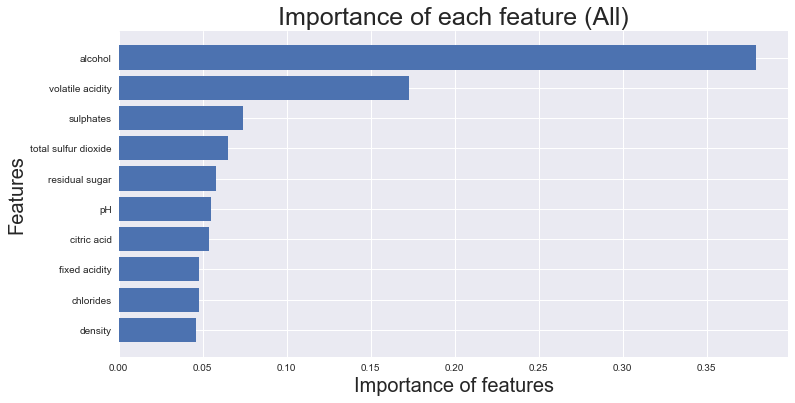

```python
# feature importance
imp = rf_final.feature_importances_
names = xtrain.columns
imp, names = zip(*sorted(zip(imp, names)))

imp = imp[-15:]
names = names[-15:]

plt.figure(figsize=(12,6))
plt.barh(range(len(names)), imp, align = 'center')
plt.yticks(range(len(names)), names)

plt.xlabel('Importance of features', fontsize = 20)
plt.ylabel('Features', fontsize = 20)
plt.title('Importance of each feature (All)', fontsize = 25)
plt.show()
```

It is seen that alcohol is the most important factor, while the density is the least important one.

```python
# predict
y_train_pred_rf = rf_final.predict(xtrain)
y_valid_pred_rf = rf_final.predict(xtest)
# print the evaluation metrics
print('Random Forest Training MSE:', mean_squared_error(ytrain, y_train_pred_rf))
print('Random Forest Training R2:', r2_score(ytrain, y_train_pred_rf))
print('Random Forest Validation MSE:', mean_squared_error(ytest, y_valid_pred_rf))
print('Random Forest Validation R2:', r2_score(ytest, y_valid_pred_rf))
```

```
Random Forest Training MSE: 0.2895512814691145
Random Forest Training R2: 0.619875959916304
Random Forest Validation MSE: 0.4538818467066293
Random Forest Validation R2: 0.40585345512313586
```

The metrics are improved than MLR model!

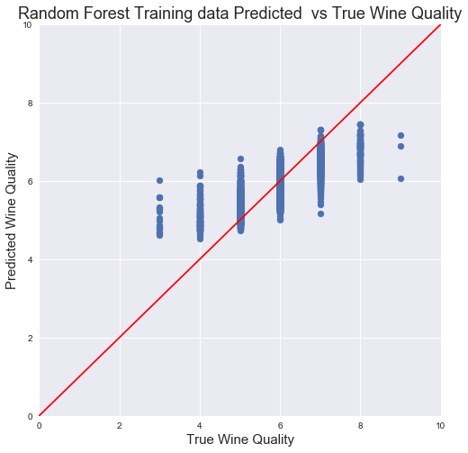

```python
fig = plt.figure(figsize=(8,8))
ax = fig.add_subplot(1,1,1)
ax.scatter(ytrain, y_train_pred_rf)
ax.plot([0, 10], [0, 10], 'r-')
ax.set_xlim([0, 10])
ax.set_ylim([0, 10])
ax.set_xlabel('True Wine Quality', fontsize = 15)
ax.set_ylabel('Predicted Wine Quality', fontsize = 15)
ax.set_title('Random Forest Training data Predicted  vs True Wine Quality', fontsize = 18)
plt.show()
```

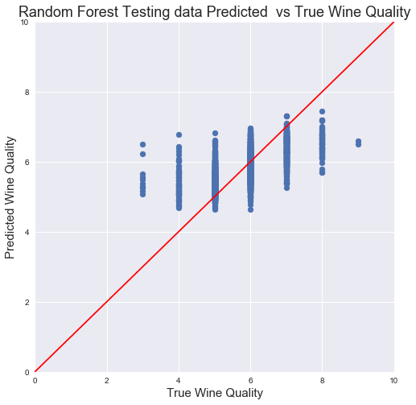

```python
fig = plt.figure(figsize=(8,8))
ax = fig.add_subplot(1,1,1)
ax.scatter(ytest, y_valid_pred_rf)
ax.plot([0, 10], [0, 10], 'r-')
ax.set_xlim([0, 10])
ax.set_ylim([0, 10])
ax.set_xlabel('True Wine Quality', fontsize = 15)
ax.set_ylabel('Predicted Wine Quality', fontsize = 15)
ax.set_title('Random Forest Testing data Predicted  vs True Wine Quality', fontsize = 18)
plt.show()
```

#### Summary:

Two regression models are built: MLR and random forest. The latter is an ensemble method, so even the predicted values are highly imbalanced, we can still get reasonable prediction. Random forest is better than MLR.  
There are other methods to try too, like Lasso, Ridge, Elastic net. But these regularization methods are used to improve overfitting. From part 2, it seems we have undersampled data for some classes. So I skipped them here.

## Part 4. Classification Model

Only random forest classifcation is used here. The boosting techniques could improve the model. Due to time limit, I will skip in this study.

```python
# I will use the normalized or scaled data here
from sklearn.ensemble import RandomForestClassifier
from sklearn.model_selection import cross_val_predict,cross_val_score
clf = RandomForestClassifier()
print(np.mean(cross_val_score(clf, x_tascale, ytrain, cv=20)))
```

```
0.6233519668467407
```

The accuracy score here is 0.623

```python
## This part can be commented once it's done. To find the best parameter.
## Can reference Part 3, RF regressor part
#param_grid = {
#                 'n_estimators': [10,20, 50, 100, 200,300],
#          #       'max_depth': ['None',5]
#             }
#
#grid_clf = GridSearchCV(clf, param_grid, cv=10)
#grid_clf.fit(x_tascale, ytrain)
## check the best parameters
#grid_clf.grid_scores_
#grid_clf. best_params_
```

[output not shown]

```python
clf = RandomForestClassifier(n_estimators=100)
clf.fit(x_tascale, ytrain)
clf.score(x_tascale, ytrain)
yrfc=clf.predict(x_ts)
print(clf.feature_importances_)
```

```
[0.08257917 0.1101806  0.08663018 0.09229271 0.09438764 0.10349411
 0.10941851 0.09261911 0.09617259 0.13222539]
```

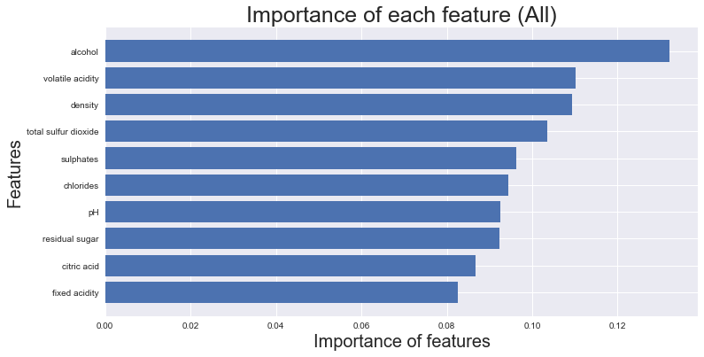

```python
imp = clf.feature_importances_
names = xtrain.columns
imp, names = zip(*sorted(zip(imp, names)))

imp = imp[-15:]
names = names[-15:]

plt.figure(figsize=(12,6))
plt.barh(range(len(names)), imp, align = 'center')
plt.yticks(range(len(names)), names)

plt.xlabel('Importance of features', fontsize = 20)
plt.ylabel('Features', fontsize = 20)
plt.title('Importance of each feature (All)', fontsize = 25)
plt.show()
```

**Comment**: The feature of importance is different from the regression model, with all variables contribute to similar level. "Alcohol" is still the most important feature. But "Density" is important too.

```python
# now use confusion matrix to evaluate the model
from sklearn.metrics import classification_report
sig_score = clf.score(x_ts, yrfc)
#target_names=['1','2','3']
ytest=ytest.astype('int64')
ytest.dtype
yrfc.dtype
print(classification_report(ytest, yrfc))
```

```
             precision    recall  f1-score   support

          3       0.00      0.00      0.00        10
          4       0.91      0.14      0.25        70
          5       0.73      0.70      0.72       703
          6       0.64      0.79      0.70       942
          7       0.65      0.51      0.58       352
          8       0.81      0.33      0.47        66
          9       0.00      0.00      0.00         2

avg / total       0.68      0.67      0.66      2145
```

We can see that for class 3 and 9, the metric is zero, because the small number of instance for this class!  
Class 5-7 has better metrics.

```python
y_train_pred=clf.predict(x_tascale)  # predict the testing
```

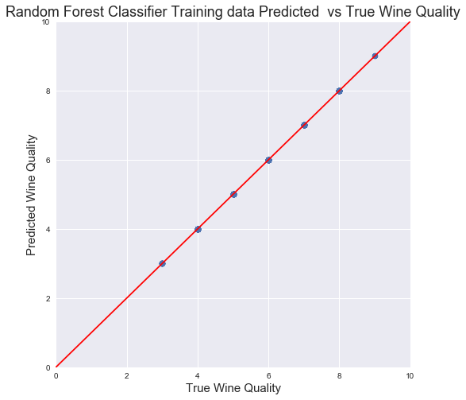

```python
fig = plt.figure(figsize=(8,8))
ax = fig.add_subplot(1,1,1)
ax.scatter(ytrain, y_train_pred)
ax.plot([0, 10], [0, 10], 'r-')
ax.set_xlim([0, 10])
ax.set_ylim([0, 10])
ax.set_xlabel('True Wine Quality', fontsize = 15)
ax.set_ylabel('Predicted Wine Quality', fontsize = 15)
ax.set_title('Random Forest Classifier Training data Predicted  vs True Wine Quality', fontsize = 18)
plt.show()
```

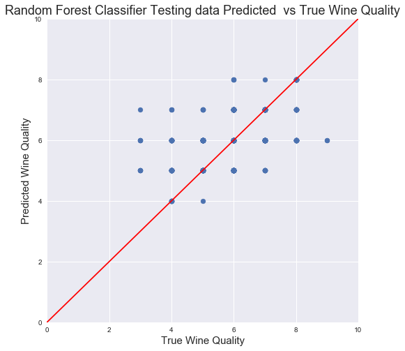

```python
fig = plt.figure(figsize=(8,8))
ax = fig.add_subplot(1,1,1)
ax.scatter(ytest, yrfc)
ax.plot([0, 10], [0, 10], 'r-')
ax.set_xlim([0, 10])
ax.set_ylim([0, 10])
ax.set_xlabel('True Wine Quality', fontsize = 15)
ax.set_ylabel('Predicted Wine Quality', fontsize = 15)
ax.set_title('Random Forest Classifier Testing data Predicted  vs True Wine Quality', fontsize = 18)
plt.show()
```

#### Summary:

A Random Forest classifier is built to predict the wine quality. The output is integer here, not a floating or continuous number as in regression model. Still the model suffers from the imbalanced data, so it failed to predict the class 9 and 3. Class 5-7 have general good result.